# An example of how to use the Gibbs sampler

04 January 2022

I was watching some videos of the very recommended youtube list of Ben Lambert called A Student’s Guide to Bayesian Statistics, and I found an example which I think it’s pretty interesting. The video in question is this: [How to derive a Gibbs sampling routine in general](https://youtu.be/9e4uqODjooo).

Here, I just wanted to replicate his results by implementing the Gibbs algorithm in R and analyse a bit more the results.

## Problem

- Each experiment consists in flipping a coin **n** times and counting the number of heads.
- We call the probability that the coin is head, as opposed to tail, as $\theta$.
- We repeat the experiment **K** times.

Basically we have a sample of $K$ binomials ($X \sim Bin(x,n,p)$) and we want to estimate both parameters of the distribution ($n$ and $\theta$).

**The notation is the following:**

- $X:$ Number of heads in $n$ coin tosses
- Repeat the experiment(X) K times: $X_1, ... , X_K$
- We have 10 observations with the following values:  
  (2, 4, 3, 3, 3, 2, 3, 3, 4, 4)

$$\text{Likelihood function for an } X_i: \\
P(x_i|\theta,n) = Bin(x_i;p,n) = {n \choose x_i} \ \theta^{x_i} (1-\theta)^{n-x_i}
\\
Priors: \\
\theta \sim U[0,1] = beta(1,1) \\
n \sim DU[5,8]$$

Since we want to infer the parameters, we have to estimate the posterior distribution. In order to do that, I will use the Gibbs sampling algorithm, which requires knowing the conditional distribution of each parameter.

First we obtain the expression for the likelihood of the sample:

$$P(n,\theta|x_1...x_K) \propto P(n,\theta,x_1...x_K) = P(x_1...x_K| n, \theta) \cdot P(n,\theta) \propto P(x_1...x_K| n, \theta) = \Pi^K_i P(x_i|n,\theta)$$
$$\Pi^K_i P(x_i|n,\theta) = \theta^{\sum x_i} (1-\theta)^{\sum n-x_i} \ \Pi_i^K \ {n \choose x_i} = \\
= \theta^{K\bar{x}} (1-\theta)^{nK-k\bar{x} } \ \Pi_i^K \ {n \choose x_i}$$

From here, we can deduce the conditional probabilities of the parameters:

$$P(\theta|n,x_1...x_K) \propto \theta^{K\bar{x}} (1-\theta)^{nK-K\bar{x}} \\
P(n|\theta,x_1...x_K) \propto (1-\theta)^{nK} \ \Pi_i^K \ {n \choose x_i}$$

For the conditional of $\theta$ we can see that the functional form obtained resembles a beta distribution.  
For the conditional of $n$ it’s not as straigthforward to find the analytical form of the density function. But since $n$ can only take 4 values (according to our prior knowledge), it’s easy to normalize the probabilities.

$$p_i = \frac{ (1-\theta)^{n_i K} \ \Pi_i^K \ {n_i \choose x_i} }{\sum_i^4 [(1-\theta)^{n_i K} \ \Pi_i^K \ {n_i \choose x_i} ] }$$
Where $i \in {5,6,7,8}$.
We can consider $P(n|\theta,x_1...x_K)$ a categorical distribution (or generalized bernuilli) with 4 possible values and with the probabilities calculated as above. To sample from this distribution we can just use the function *rcat* from the package extraDistr.

The code to sample from $n$ conditional is the following:

```r
categ.n <- function(theta, values_n, K, data){
  # Inputs:
  # theta:
  # values_n: values specified in the prior of n (in this case 5,6,7,8)
  # K: number of experiments (in this case 0)

  # calculate the unnormalized P(n|·) for all the values of n
  cond.n <- function(theta, values_n, K){
   power <- (1-theta)^(values_n*K)
   prod_combn <- apply(sapply(data, choose, n=values_n ), 1,  prod)
   return( power*prod_combn )
  }

  # normalize each term by diving by the total
  probabilities_n <- cond.n( theta, values_n, K ) / sum( cond.n( theta, values_n, K ) )
  # using the probabilities calculated generate a random sample
  random_n <- as.numeric( as.character( extraDistr::rcat(n=1, prob= probabilities_n, labels=values_n) ) )

  return(random_n)
}
```

Therefore, the posterior distributions are:

$$P( \theta_{t+1}| \ n_t, \ x_1 ... x_K) \sim beta(K \cdot \bar{x} + 1, \ K(n-\bar{x}) + 1) \\
P(n_{t+1}| \ \theta_{t+1}, \ x_1 ... x_K) \sim categ(p_1, p_2, p_3, p_4)$$

## Implementation

### Data

We have 10 observations and so we can already see that $n$ has to be at least 4.

```r
data = c(2, 4, 3, 3, 3, 2, 3, 3, 4, 4)
summary(data)
```

```
##    Min. 1st Qu.  Median    Mean 3rd Qu.    Max.
##    2.00    3.00    3.00    3.10    3.75    4.00
```

```r
table(data)
```

```
## data
## 2 3 4
## 2 5 3
```

### Steps of the Gibbs sampler

1. Derive an expression for the conditional distribution of each parameter
2. Set some initial values for theta and n (within the support)
3. Sample from $\theta_{t+1}|n_t,x_{1}...x_{K}$ and then from $n_{t+1}|\theta_{t+1},x_{1}...x_{K}$
4. Repeat (3.) until you are reasonably sure that the convergence to the posterior is good
5. Diagnostics and others

### Gibbs sampler

```r
sampleGibbs <- function(ini.theta, ini.n, n.sims, data){

  K <- length(data)
  avg <- mean(data)
  values_n <- 5:8 # from the prior

  # create empty matrix, more efficient
  sim <- matrix(NA, nrow = n.sims, ncol = 2)
  sim[1,] <- c(ini.theta, ini.n)

  for (i in 2:n.sims){
    # sample the values of the parameters
    sim[i,1] <- rbeta(1, shape1= K*avg + 1, shape2= K*(sim[i-1,2]-avg) + 1) # theta
    sim[i,2] <- categ.n(sim[i,1], values_n, K, data)                        # n
  }
  return(sim)
}
```

## Results

To get an idea of what the algorithm is doing we can try first with **50 iterations**.

```r
n_simulations = 50

# ini.theta= runif(1,0,1), ini.n=sample(5:8,1)
results <- sampleGibbs(ini.theta= 0.5, ini.n= 6, n.sims= n_simulations, data= data)
theta.post <- results[,1]
n.post <- results[,2]
```

We can look at the joint density of $\theta$ and $n$, the traceplot for each parameter or the density of the posterior.

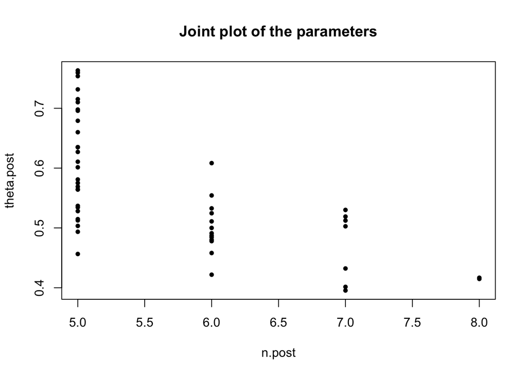

```r
plot(n.post, theta.post, pch = 20, main="Joint plot of the parameters")
```

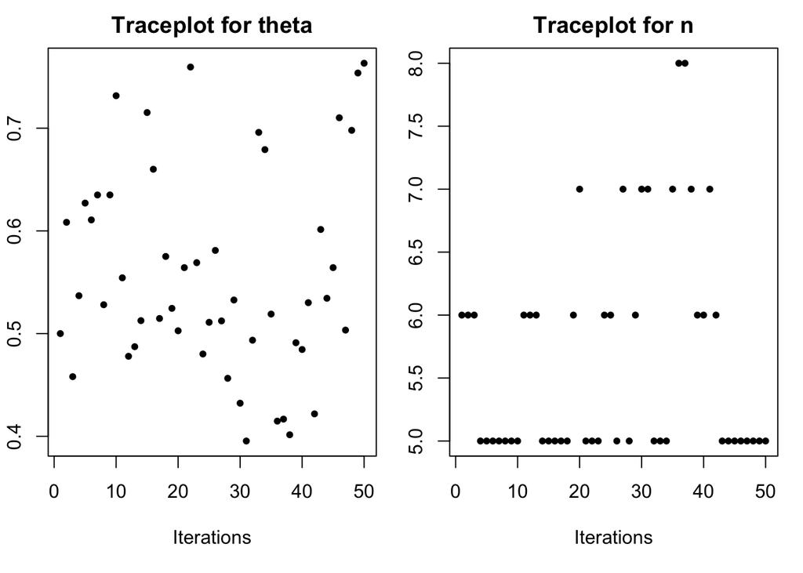

```r
par(mfrow=c(1,2), mar=c(5,2,2,1)+0.1)
plot(1:n_simulations, theta.post, pch = 20, main="Traceplot for theta", xlab="Iterations")
plot(1:n_simulations, n.post, pch = 20, main="Traceplot for n", xlab="Iterations")
```

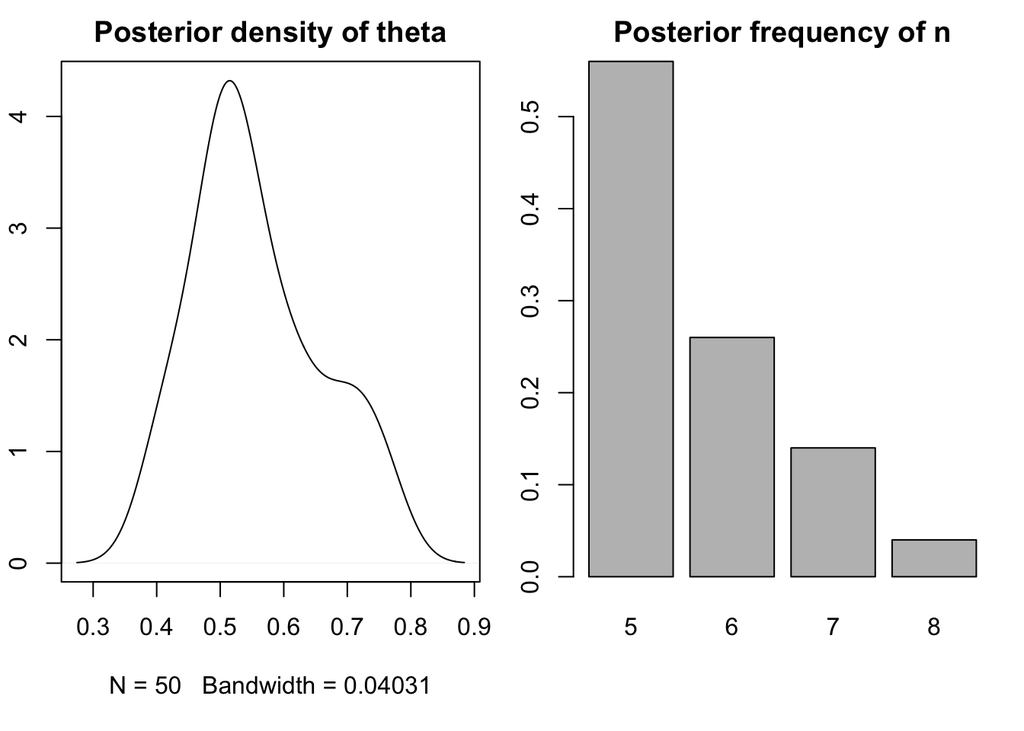

```r
plot(density(theta.post), main="Posterior density of theta")
barplot(table(n.post)/n_simulations, main="Posterior frequency of n")
```

**Using 10000 iterations**

```r
n_simulations = 10000

# ini.theta= runif(1,0,1), ini.n=sample(5:8,1)
results <- sampleGibbs(ini.theta= 0.5, ini.n= 6, n.sims= n_simulations, data= data)
theta.post <- results[,1]
n.post <- results[,2]
```

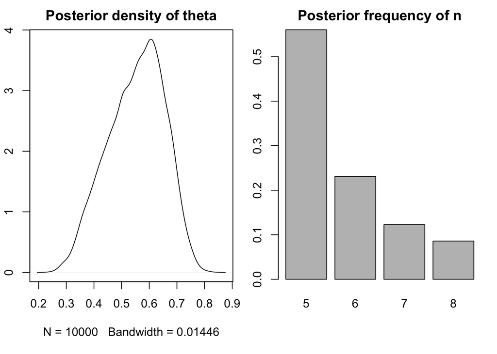

```r
par(mfrow=c(1,2), mar=c(5,2,2,1)+0.1)
plot(density(theta.post), main="Posterior density of theta")
barplot(table(n.post)/n_simulations, main="Posterior frequency of n")
```

```r
summary(theta.post)
```

```
##    Min. 1st Qu.  Median    Mean 3rd Qu.    Max.
##  0.2387  0.4802  0.5618  0.5521  0.6288  0.8318
```

```r
summary(n.post)
```

```
##    Min. 1st Qu.  Median    Mean 3rd Qu.    Max.
##   5.000   5.000   5.000   5.734   6.000   8.000
```

## Simulating data

To see the difference between the estimation and the real values, I simulate a sample of 20 observations using $X \sim Bin(x,n= 6, p=0.8)$.

```r
# Parameters n=6 and theta=0.8
set.seed(11)
generated_data = rbinom(n= 20, size= 6, prob= 0.8)

n_simulations = 10000

# same initialisation values as before
results <- sampleGibbs(ini.theta= 0.5, ini.n= 6, n.sims= n_simulations, data= generated_data)
theta.post <- results[,1]
n.post <- results[,2]

summary(theta.post)
```

```
##    Min. 1st Qu.  Median    Mean 3rd Qu.    Max.
##  0.5000  0.7951  0.8247  0.8135  0.8489  0.9281
```

```r
summary(n.post)
```

```
##    Min. 1st Qu.  Median    Mean 3rd Qu.    Max.
##   6.000   6.000   6.000   6.126   6.000   8.000
```

In the case of $\theta$, the estimation using the mean is 0.81, which is close to the real value, but there is still a big margin for improvement.

### Further improvements

- **Diagnostics**: I have shown the traceplot but you could also calculate some statistics etc.
- **Burn-in**: Remove the first N (100?) iterations.
- Use of **multiple chains** (probably the most important improvement).
- **Remove consecutive observations** to avoid dependance. Estimate efective sample size.